# R Notebook

```r
library(rpart)
library(rpart.plot)
library(tidyverse)
library(modelr)
library(yardstick)
library(caret)
library(randomForest)
library(GGally)
```

```r
titanic <- read_csv("data/titanic_decision_tree_data.csv")
```

Question 1

```r
titanic_clean <- titanic %>%
  drop_na(survived, age) %>%
  mutate(sex = factor(sex),
         survived = factor(if_else(survived == 1, "Survived", "Died")),
         pclass = factor(pclass),
         embarked = factor(embarked),
         age_status = factor(if_else(age > 16, "Adult", "Child"))) %>%
  select(-c(X1, passenger_id, name, ticket, fare, cabin))
```

Question 2

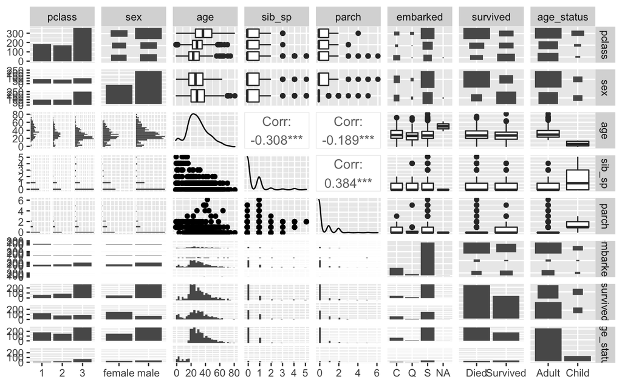

```r
titanic_clean %>%
  ggpairs()
```

From the boxplots above, it looks like pclass, sex and embarked may be variables of interest. Age status may also be a factor but hard to tell.

Question 3

```r
n_data <- nrow(titanic_clean)
```

```r
test_index <- sample(1:n_data, size = n_data * 0.2)
```

```r
titanic_test <- slice(titanic_clean, test_index)
titanic_train <- slice(titanic_clean, -test_index)
```

```r
titanic_test %>%
  janitor::tabyl(survived)
```

```
 survived  n   percent
     Died 86 0.6056338
 Survived 56 0.3943662
```

```r
titanic_train %>%
  janitor::tabyl(survived)
```

```
 survived   n   percent
     Died 338 0.5909091
 Survived 234 0.4090909
```

This split for both sets is close, so ok to proceed with analysis. The split of the data is using a random sample of 20% of the row numbers to create the test sample and the remaining rows are the training sample.

Question 4

```r
titanic_fit <- rpart(
  formula = survived ~ .,
  data = titanic_train,
  method = "class"
)
```

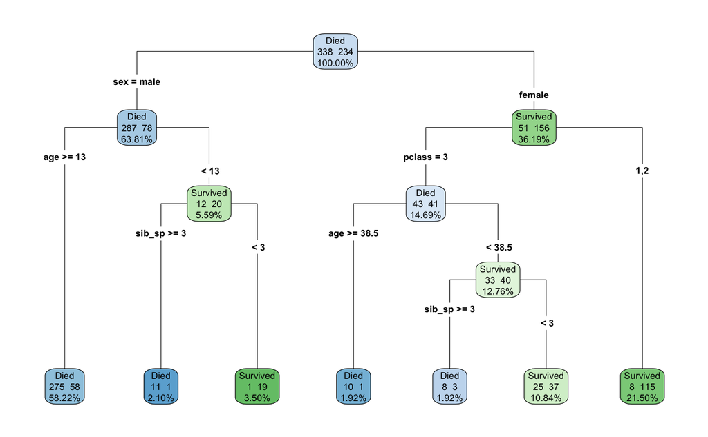

```r
rpart.plot(titanic_fit, yesno = 2, fallen.leaves = TRUE, faclen = 6, digits = 4,
           type = 4, extra = 101)
```

Question 5

For males, if you were older than 13 you were more likely to die. If you were male, under 13 and had less than 3 siblings aboard you were less likely to die (19 survived versus 1)

For females, if you were in passenger class 1,2 you had better chance of surviving versus those in passenger class 3(115 versus 41)

For those in class 3 who were female, if you were younger than 38.5 and had less than 3 siblings/spouses you were more likely to survive.

Variables of importance - sex, age, class, number siblings/spouses

Question 6

```r
titanic_test_pred <- titanic_test %>%
  add_predictions(titanic_fit, type = "class")

titanic_test_pred
```

| pclass | sex | age | sib_sp | parch | embarked | survived | age_status | pred |
| --- | --- | --- | --- | --- | --- | --- | --- | --- |
| 2 | male | 31.0 | 1 | 1 | C | Died | Adult | Died |
| 3 | male | 36.0 | 1 | 1 | S | Died | Adult | Died |
| 2 | male | 51.0 | 0 | 0 | S | Died | Adult | Died |
| 2 | male | 24.0 | 0 | 0 | S | Died | Adult | Died |
| 2 | female | 27.0 | 1 | 0 | S | Died | Adult | Survived |
| 1 | female | 56.0 | 0 | 1 | C | Survived | Adult | Survived |
| 2 | male | 26.0 | 0 | 0 | S | Died | Adult | Died |
| 3 | male | 26.0 | 2 | 0 | S | Died | Adult | Died |
| 2 | female | 32.0 | 0 | 0 | S | Survived | Adult | Survived |
| 1 | female | 42.0 | 0 | 0 | C | Survived | Adult | Survived |

[output cut: 132 more lines]

```r
confusion_matrix <- titanic_test_pred %>%
  conf_mat(truth = survived, estimate = pred)

confusion_matrix
```

```
          Truth
Prediction Died Survived
  Died       75       14
  Survived   11       42
```

Model predicted 75 people died accurately. Model predicted 42 people survived accurately.